# Lab 2 Examples

February 2, 2018

## Setup

We begin by loading the packages we will be using.

```r
library(tidyverse)
library(haven)
library(stargazer)
library(lubridate)
library(AER)
```

## Warming up at the Fulton fish market

We now proceed by loading the dataset using the `read_dta` function from the haven package (part of the tidyverse).

```r
fishmarket <- read_dta("fishmarket.dta")
```

### Present and understand your data

#### 1.

As in the previous lab, we can make a table of summary statistics using the stargazer package. Note that we can use the option `covariate.labels` to change the displayed name of variables in a Stargazer table.

```r
summarydata <- fishmarket %>%
    select(price,quan,stormy,mixed)
stargazer(as.data.frame(summarydata),
          type = "text",
          covariate.labels = c("Price",
                               "Quantity",
                               "Stormy Weather",
                               "Mixed Weather"))
```

```
=========================================================
Statistic       N    Mean    St. Dev.    Min      Max
---------------------------------------------------------
Price          111   0.885     0.335    0.330    1.943
Quantity       111 6,334.667 4,040.120 490.000 21,619.990
Stormy Weather 111   0.288     0.455      0        1
Mixed Weather  111   0.306     0.463      0        1
---------------------------------------------------------
```

#### 2.

The date variable is not in a format we want to work with at the moment, so we need to fix that. THe date variable is currently in the format year, month, day (numeric with YYMMDD), so we can format it using the function `ymd` from the lubridate package (we just replace the current date variable with the new one as we have no use for the old one).

```r
fishmarket <- fishmarket %>%
    mutate(date=ymd(date))
```

Now we can plot the quantity sold per day. A step-plot (`geom_step`) works well in this instance, making apparent the changes from date to date. In some instances, we might want to specify how the markers on the axes should be formatted. `ggplot` will usually do something sensible, but sometimes we can improve the figure by providing more detailed instructions. Here, we specify that the x-axis should be formatted as a date (`scale_x_date`) with a monthly resolution.

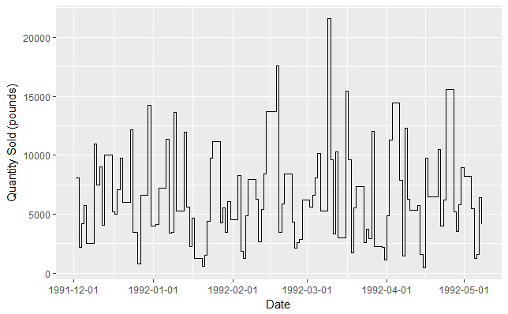

```r
ggplot(data=fishmarket,aes(x=date,y=quan)) +
    geom_step() +
    scale_x_date(date_breaks = "1 month") +
    labs(x="Date",y="Quantity Sold (pounds)")
```

Also plot the price per unit each day by filling in:

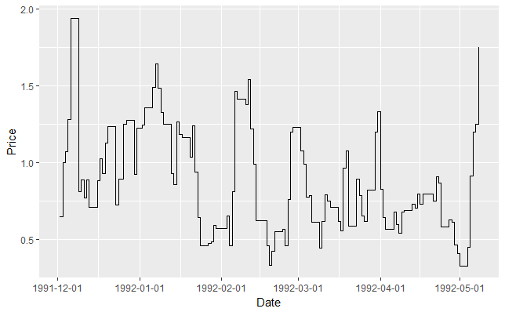

```r
ggplot(data=fishmarket,aes(x=date,y=price)) +
  geom_step() +
    scale_x_date(date_breaks = "1 month") +
    labs(x="Date",y="Price")
```

It might be easier to see how prices and quantities vary together if we place the two plots in one figure, though this requires a bit more effort to get to work “straight out of the box”:

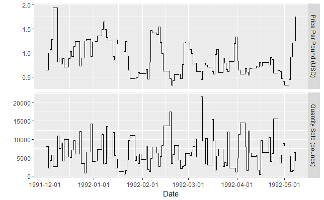

```r
fishmarket %>% select(date, price, quan) %>%
  gather(key = 'variable', value = 'value', -date) %>%
  ggplot(aes(x=date, y=value)) +
  geom_step() +
  facet_grid(variable ~ ., scales = 'free_y',
             labeller = as_labeller(c('price'='Price Per Pound (USD)', 'quan'='Quantity Sold (pounds)'))
             ) +
  scale_x_date(date_breaks = "1 month") +
  labs(x = 'Date', y = '')
```

#### 3.

Regress quantity on price and make a regression table using stargazer. Use the options `covariate.labels` to change the display of variable names in the table. You can also use `dep.var.labels` to change the header over each column.

```r
quan_price_ols <- lm(quan ~ price,
                     data=fishmarket)
stargazer(quan_price_ols,
          type="text",
          covariate.labels = c("Price"),
          dep.var.labels = c("Quantity Sold"),
          keep.stat = c("n","rsq"))
```

```
========================================
                 Dependent variable:
             ---------------------------
                    Quantity Sold
----------------------------------------
Price               -3,709.017***
                     (1,098.750)

Constant            9,615.382***
                     (1,038.695)

----------------------------------------
Observations             111
R2                      0.095
========================================
Note:        *p<0.1; **p<0.05; ***p<0.01
```

The results are probably easier to read if we scale quantity to 1000 pounds and set the number of digits after decimal to two:

```r
quant_price_ols <- lm(quan / 1000 ~ price,
                      data=fishmarket)
stargazer(quant_price_ols,
          type="text",
          digits = 2,
          covariate.labels = c("Price"),
          dep.var.labels = c("Quantity Sold (1000 pounds)"),
          keep.stat = c("n","rsq"))
```

```
========================================
                 Dependent variable:
             ---------------------------
             Quantity Sold (1000 pounds)
----------------------------------------
Price                 -3.71***
                       (1.10)

Constant               9.62***
                       (1.04)

----------------------------------------
Observations             111
R2                      0.09
========================================
Note:        *p<0.1; **p<0.05; ***p<0.01
```

Note that we can also create a table which looks nicer in the html output of the notebook by specifying the option `results='asis'` for the chunk (necessary for the final output to display the table correctly) and `type=html` for stargazer, though it becomes hard to see the results when working in the raw notebook directly (optionally, one can also set the option `style` to give the table a particular format, as shown here). You need to save the file, click *Preview* and choose *Preview Notebook* to see how the final result looks like in the Viewer.

```r
stargazer(quant_price_ols,
          type="html",
          style='aer',
          digits = 2,
          covariate.labels = c("Price"),
          dep.var.labels = c("Quantity Sold (1000 pounds)"),
          keep.stat = c("n","rsq"))
```

|  | Quantity Sold (1000 pounds) |
| --- | --- |
| Price | -3.71*** |
|  | (1.10) |
| Constant | 9.62*** |
|  | (1.04) |
| Observations | 111 |
| R<sup>2</sup> | 0.09 |
| *Notes:* | ***Significant at the 1 percent level. |
|  | **Significant at the 5 percent level. |
|  | *Significant at the 10 percent level. |

### Assessing and understanding IV

#### 4.

To make this plot, we have to generate a variable showing if the weather is stormy, mixed or clear at sea.

```r
fishmarket <- fishmarket %>%
    mutate(weather=ifelse(stormy==1,"High wind and waves",
                          ifelse(mixed==1,"Mixed wind and waves",
                                 NA)))
```

We can now make the plot. This involves invoking the `fill` aesthetic of ggplot, which will make columns of separate color for the weather-type. The option `alpha` tells ggplot how opaque or transparent we want the element to be, where a lower value means more transparent, which can help with making other features easier to see (like the price series here). We filter out the `NA`-values from the variable *weather* using the `filter`-function (from the tidyverse package dplyr), so that these do not feature with a fill-color or in the legend of the plot. `scale_fill_brewer` allows us to choose the color scheme for the `fill`-aesthetic that we’ve chosen, which we optionally can provide with a name, otherwise the default is the variable name (weather, with lower-case initial).

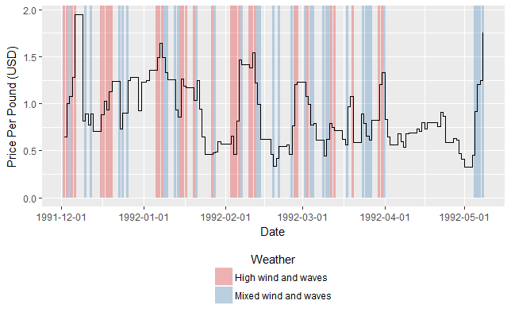

```r
ggplot(data=fishmarket,aes(x=date,y=price)) +
    geom_col(data=filter(fishmarket,!is.na(weather)),
             aes(y=Inf,fill=weather),
             alpha=0.3) +
    geom_step() +
    scale_fill_brewer(name = "Weather", palette = "Set1") +
    scale_x_date(date_breaks = "1 month") +
    labs(x="Date",y="Price Per Pound (USD)") +
    theme(legend.position = "bottom",
          legend.direction = "vertical",
          legend.title.align = 0.5)
```

#### 5.

Fill in to estimate the relevant regression equations and present them in a table using stargazer (tip: use quantity in thousands.

```r
price_stormy_ols <- lm(price ~ weather, data=fishmarket)
quan_stormy_ols <- lm(quan/1000 ~ weather, data = fishmarket)
stargazer(price_stormy_ols,quan_stormy_ols,
          type="text",
          covariate.labels = c("Stormy Weather"),
          dep.var.labels = c("Price","Quantity"),
          keep.stat = c("n","rsq"),
          digits=3)
```

```
===========================================
                   Dependent variable:
               ----------------------------
                   Price        Quantity
                    (1)            (2)
-------------------------------------------
Stormy Weather    -0.200**       1.670*
                  (0.081)        (0.946)

Constant          1.106***      4.787***
                  (0.058)        (0.679)

-------------------------------------------
Observations         66            66
R2                 0.087          0.046
===========================================
Note:           *p<0.1; **p<0.05; ***p<0.01
```